# DSC540 Project 2

DePaul University  
Ilyas Ustun, PhD  
Chicago, IL

## Rules

- Do not change the code already present in the notebook.
- Write your code under the corresponding questions where you see `# Code here`. You are encouraged to use more than one cell.
- Provide explanation in a separate Markdown formatted cell.
- You can change the cell type by:
  - Clicking on the outer area of the cell type you want to change,
  - Go to the top, and select either Code or Markdown from the dropdown menu.
- Be concise in your explanations and conclusions.
- Write clear code and provide explanation to functions you create by using `#` comment sign.
- For built-in function and methods you use from libraries, provide a very brief explanation of what they do.
- Try to answer the questions by yourself. Use documentation from pandas, sklearn and similar libraries to solve the problem.
- If you are stuck you can use different resources. Do not find an identical project and copy paste the solutions.
- Write your name before beginning to code.

> **Once you have completed your project, and you are done with coding restart your kernel and run everything. Make sure it runs without errors.**

> ```
> - For this go to the very top where the tabs are located:
>     - Kernel
>         - Restart & Run All
> - We will check whether the code and results in this notebook is running fine.
> ```

Important:

- **Do NOT share the solutions with other people.**
- **Do NOT share the solutions on the internet including but not limited to Github and other platforms.**
- Sign the Honor Pledge below indicating that you have agreed to these rules listed here, and any other ethical and honor rules as required by the university.
- **Deliverables:**
  1. The Python Jupyter notebook file named properly with your name. Example: dsc540_project1_john_doe.ipynb
  2. The HTML output of this code notebook names the same way. Example: dsc540_project1_john_doe.html
     - File -> Download as -> HTML
  3. The label predictions as csv file. -> See last question.

Good Luck!

### Keiland Pullen

**Honor Pledge:**  
I pledge on my honor that I, **Keiland Pullen**, have followed the rules listed above, that I have not given or received any unauthorized assistance on this assignment.

## Project Description

For this project we will be exploring publicly available data from LendingClub.com.  
Lending Club connects people who need money (borrowers) with people who have money (investors).  
Hopefully, as an investor you would want to invest in people who showed a profile of having a high probability of paying you back. We will try to create a model that will help predict this.

Check out more info on Lending Club on [Wikipedia](https://en.wikipedia.org/wiki/Lending_Club). Lending Club also had a [very interesting year in 2016](https://en.wikipedia.org/wiki/Lending_Club#2016).

This dataset is from before they went public.

We will use lending data from 2007-2010 and will try to classify and predict whether or not the borrower paid back their loan in full. You will analyze the data file provided.

## Import Libraries

**Import the usual libraries for pandas and plotting, and sklearn.**

```python
import pandas as pd
import numpy as np
import matplotlib.pyplot as plt
import seaborn as sns
```

```python
import sklearn
sklearn.__version__
```

```
'0.24.2'
```

```python
pd.set_option('display.max_columns', 100)
```

### These are the packages I used

```python
# Your package imports here
import os
```

# Q1

- Read in the dataset `loan_data.csv`
- How many rows and variables are there?
- What are the unique values of `not.fully.paid`?
- `not.fully.paid` having a value of 1 means that the person who took the loan did not fully pay it back. What's the proportion of those people in the full dataset?

# Ans1

- Datasets have been read in.
- There are 7478 rows and 14 variables in the `loans file`.
- There are 2100 rows and 13 variables in the `loans_outcome_not_known` file.
- `not.fully.paid` has 2 unique values, 1 or 0.
- The proportion of `not.fully.paid` values are: -- 0 6045 -- 1 1433

## Get the Data

**Use pandas to read loan_data.csv as a dataframe called loans.**

```python
pwd
```

```
'C:\\Users\\Home'
```

```python
hwDir = "C:/Users/Home/Desktop/DePaul/Winter - DSC - 540 - Advanced Machine Learning/Week 3/Homework"
os.chdir(hwDir)
```

```python
pwd
```

```
'C:\\Users\\Home\\Desktop\\DePaul\\Winter - DSC - 540 - Advanced Machine Learning\\Week 3\\Homework'
```

```python
loans = pd.read_csv('loans_train.csv')
loans_outcome_not_known = pd.read_csv('loans_outcome_not_known.csv')
```

```python
loans.head()
```

|  | credit.policy | purpose | int.rate | installment | log.annual.inc | dti | fico | days.with.cr.line | revol.bal | revol.util | inq.last.6mths | delinq.2yrs | pub.rec | not.fully.paid |
| --- | --- | --- | --- | --- | --- | --- | --- | --- | --- | --- | --- | --- | --- | --- |
| 0 | 1 | credit_card | 0.0800 | 101.85 | 10.596635 | 10.26 | 747 | 7560.000000 | 18467 | 30.9 | 3 | 0 | 0 | 0 |
| 1 | 1 | all_other | 0.1114 | 328.04 | 10.530495 | 14.13 | 722 | 1920.000000 | 6811 | 56.8 | 0 | 0 | 0 | 0 |
| 2 | 1 | debt_consolidation | 0.1324 | 676.20 | 11.289782 | 20.73 | 697 | 4080.000000 | 16805 | 64.1 | 0 | 0 | 0 | 0 |
| 3 | 1 | debt_consolidation | 0.1103 | 671.44 | 10.555813 | 15.72 | 722 | 3580.041667 | 31566 | 32.3 | 1 | 0 | 0 | 1 |
| 4 | 0 | debt_consolidation | 0.1545 | 244.21 | 10.308953 | 18.80 | 647 | 1950.041667 | 4587 | 41.0 | 2 | 0 | 0 | 0 |

```python
loans_outcome_not_known.head()
```

|  | credit.policy | purpose | int.rate | installment | log.annual.inc | dti | fico | days.with.cr.line | revol.bal | revol.util | inq.last.6mths | delinq.2yrs | pub.rec |
| --- | --- | --- | --- | --- | --- | --- | --- | --- | --- | --- | --- | --- | --- |
| 0 | 1 | debt_consolidation | 0.1324 | 540.96 | 10.596635 | 11.73 | 672 | 3210.000000 | 5671 | 55.1 | 0 | 0 | 0 |
| 1 | 0 | educational | 0.1221 | 333.15 | 11.156193 | 15.82 | 707 | 5314.000000 | 107643 | 81.0 | 3 | 0 | 0 |
| 2 | 1 | debt_consolidation | 0.1218 | 166.50 | 10.753836 | 6.38 | 772 | 1440.000000 | 233 | 6.7 | 0 | 0 | 0 |
| 3 | 0 | major_purchase | 0.1461 | 124.12 | 10.239960 | 0.00 | 692 | 1530.041667 | 0 | 0.0 | 6 | 0 | 0 |
| 4 | 1 | credit_card | 0.0800 | 156.69 | 10.434116 | 15.85 | 767 | 10170.000000 | 5748 | 12.3 | 0 | 1 | 0 |

**Check out the info(), head(), and describe() methods on loans.**

```python
loans.info()
```

```
<class 'pandas.core.frame.DataFrame'>
RangeIndex: 7478 entries, 0 to 7477
Data columns (total 14 columns):
 #   Column             Non-Null Count  Dtype
---  ------             --------------  -----
 0   credit.policy      7478 non-null   int64
 1   purpose            7478 non-null   object
 2   int.rate           7478 non-null   float64
 3   installment        7478 non-null   float64
 4   log.annual.inc     7478 non-null   float64
 5   dti                7478 non-null   float64
 6   fico               7478 non-null   int64
 7   days.with.cr.line  7478 non-null   float64
 8   revol.bal          7478 non-null   int64
 9   revol.util         7478 non-null   float64
 10  inq.last.6mths     7478 non-null   int64
 11  delinq.2yrs        7478 non-null   int64
 12  pub.rec            7478 non-null   int64
 13  not.fully.paid     7478 non-null   int64
dtypes: float64(6), int64(7), object(1)
memory usage: 818.0+ KB
```

```python
loans.describe()
```

|  | credit.policy | int.rate | installment | log.annual.inc | dti | fico | days.with.cr.line | revol.bal | revol.util | inq.last.6mths | delinq.2yrs | pub.rec | not.fully.paid |
| --- | --- | --- | --- | --- | --- | --- | --- | --- | --- | --- | --- | --- | --- |
| count | 7478.000000 | 7478.000000 | 7478.000000 | 7478.000000 | 7478.000000 | 7478.000000 | 7478.000000 | 7.478000e+03 | 7478.000000 | 7478.000000 | 7478.000000 | 7478.000000 | 7478.000000 |
| mean | 0.800615 | 0.123130 | 322.555320 | 10.936374 | 12.624763 | 710.180663 | 4543.688470 | 1.729738e+04 | 46.917329 | 1.618748 | 0.161942 | 0.063921 | 0.191629 |
| std | 0.399565 | 0.026727 | 208.950622 | 0.621971 | 6.896500 | 37.537593 | 2477.818646 | 3.601391e+04 | 28.982548 | 2.244517 | 0.530832 | 0.263576 | 0.393609 |
| min | 0.000000 | 0.060000 | 15.670000 | 7.547502 | 0.000000 | 612.000000 | 180.041667 | 0.000000e+00 | 0.000000 | 0.000000 | 0.000000 | 0.000000 | 0.000000 |
| 25% | 1.000000 | 0.105100 | 165.425000 | 10.555813 | 7.200000 | 682.000000 | 2820.000000 | 3.109000e+03 | 23.000000 | 0.000000 | 0.000000 | 0.000000 | 0.000000 |
| 50% | 1.000000 | 0.122900 | 271.110000 | 10.933107 | 12.680000 | 707.000000 | 4110.041667 | 8.654000e+03 | 46.600000 | 1.000000 | 0.000000 | 0.000000 | 0.000000 |
| 75% | 1.000000 | 0.141100 | 441.600000 | 11.302204 | 17.992500 | 737.000000 | 5700.958333 | 1.827000e+04 | 70.775000 | 2.000000 | 0.000000 | 0.000000 | 0.000000 |
| max | 1.000000 | 0.216400 | 940.140000 | 14.180154 | 29.960000 | 822.000000 | 17639.958330 | 1.207359e+06 | 119.000000 | 33.000000 | 13.000000 | 5.000000 | 1.000000 |

```python
loans_outcome_not_known.info()
```

```
<class 'pandas.core.frame.DataFrame'>
RangeIndex: 2100 entries, 0 to 2099
Data columns (total 13 columns):
 #   Column             Non-Null Count  Dtype
---  ------             --------------  -----
 0   credit.policy      2100 non-null   int64
 1   purpose            2100 non-null   object
 2   int.rate           2100 non-null   float64
 3   installment        2100 non-null   float64
 4   log.annual.inc     2100 non-null   float64
 5   dti                2100 non-null   float64
 6   fico               2100 non-null   int64
 7   days.with.cr.line  2100 non-null   float64
 8   revol.bal          2100 non-null   int64
 9   revol.util         2100 non-null   float64
 10  inq.last.6mths     2100 non-null   int64
 11  delinq.2yrs        2100 non-null   int64
 12  pub.rec            2100 non-null   int64
dtypes: float64(6), int64(6), object(1)
memory usage: 213.4+ KB
```

```python
loans_outcome_not_known.describe()
```

|  | credit.policy | int.rate | installment | log.annual.inc | dti | fico | days.with.cr.line | revol.bal | revol.util | inq.last.6mths | delinq.2yrs | pub.rec |
| --- | --- | --- | --- | --- | --- | --- | --- | --- | --- | --- | --- | --- |
| count | 2100.000000 | 2100.000000 | 2100.000000 | 2100.000000 | 2100.000000 | 2100.000000 | 2100.000000 | 2100.000000 | 2100.000000 | 2100.000000 | 2100.00000 | 2100.000000 |
| mean | 0.820476 | 0.120896 | 306.747486 | 10.916959 | 12.542281 | 713.216667 | 4621.583730 | 15548.628571 | 46.378710 | 1.430476 | 0.17000 | 0.055714 |
| std | 0.383882 | 0.027204 | 199.796686 | 0.588511 | 6.840411 | 39.391612 | 2563.507241 | 24010.740760 | 29.130651 | 2.028483 | 0.59788 | 0.256856 |
| min | 0.000000 | 0.060000 | 16.310000 | 8.294050 | 0.000000 | 612.000000 | 178.958333 | 0.000000 | 0.000000 | 0.000000 | 0.00000 | 0.000000 |
| 25% | 1.000000 | 0.099600 | 157.452500 | 10.571317 | 7.227500 | 682.000000 | 2760.041667 | 3450.500000 | 21.400000 | 0.000000 | 0.00000 | 0.000000 |
| 50% | 1.000000 | 0.121800 | 262.145000 | 10.915088 | 12.590000 | 707.000000 | 4229.958333 | 8449.000000 | 45.350000 | 1.000000 | 0.00000 | 0.000000 |
| 75% | 1.000000 | 0.138500 | 413.695000 | 11.289782 | 17.850000 | 742.000000 | 5850.000000 | 18112.000000 | 71.700000 | 2.000000 | 0.00000 | 0.000000 |
| max | 1.000000 | 0.212100 | 922.420000 | 14.528354 | 29.720000 | 827.000000 | 16350.000000 | 255001.000000 | 106.100000 | 28.000000 | 11.00000 | 4.000000 |

```python
percentage = loans['not.fully.paid'].value_counts()

print(percentage)
```

```
0    6045
1    1433
Name: not.fully.paid, dtype: int64
```

# Q2

- Visual and Exploratory Analysis
- Carry out the tasks given below

## Exploratory Data Analysis

- Let's do some data visualization!
- You can use many different visualization libraries inclusing matplotlib, seaborn, pandasand many more. Feel free to use whatever library you want. Don't worry about the colors matching, just worry about getting the main idea of the plot.

**Create a histogram of two FICO distributions on top of each other, one for each credit.policy outcome.**

*Note: You'll probably need one line of code for each histogram, I also recommend just using pandas built in .hist()*

```
credit.policy
0    AxesSubplot(0.125,0.125;0.775x0.755)
1    AxesSubplot(0.125,0.125;0.775x0.755)
Name: fico, dtype: object
```

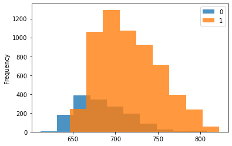

```python
# loans.hist(column='fico', sharex=True, by=loans['credit.policy'])

loans.groupby('credit.policy')['fico'].plot(kind='hist', legend=True, alpha=0.8)
```

**Create a similar figure, except this time select by the not.fully.paid column.**

```
not.fully.paid
0    AxesSubplot(0.125,0.125;0.775x0.755)
1    AxesSubplot(0.125,0.125;0.775x0.755)
Name: fico, dtype: object
```

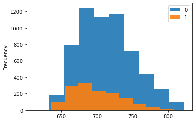

```python
loans.groupby('not.fully.paid')['fico'].plot(kind='hist', legend=True, alpha=0.9)
```

**Create a countplot (bar plot showing counts using seaborn) that shows the counts of loans by purpose, with the color hue defined by `not.fully.paid`**

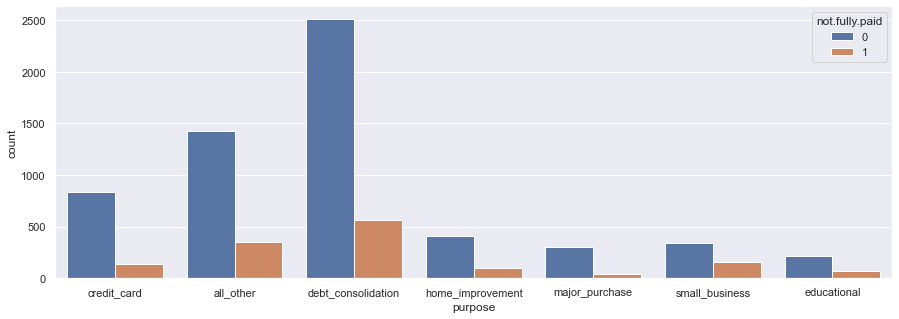

```python
sns.set(rc={"figure.figsize":(15, 5)}) #width=6, height=5

sns.countplot(x ='purpose', hue = "not.fully.paid", data = loans)

# Show the plot
plt.show()
```

**Let's see the trend between FICO score and interest rate. Recreate the following jointplot.**

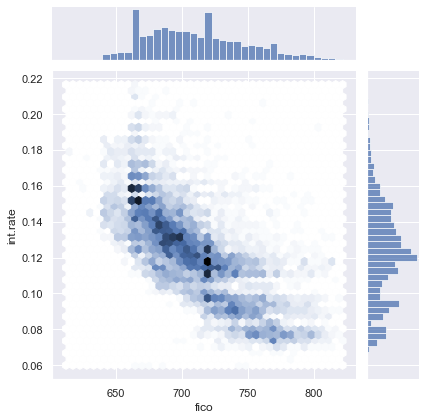

```python
sns.jointplot(x = "fico", y = "int.rate",
              kind = "hex", data = loans)
# show the plot
plt.show()
```

**Create the following lmplots to see if the trend differed between `not.fully.paid` and `credit.policy`. Check the documentation for seaborn `lmplot()` if you can't figure out how to separate it into columns.**

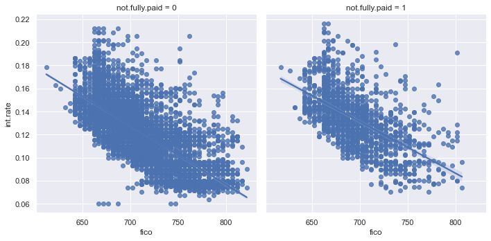

```python
sns.lmplot(x="fico", y="int.rate", col="not.fully.paid", data=loans)
```

# Q3

## Setting up the Data

Let's get ready to set up our data for our models!

**Check loans.info() again.**

```python
loans.info()
```

```
<class 'pandas.core.frame.DataFrame'>
RangeIndex: 7478 entries, 0 to 7477
Data columns (total 14 columns):
 #   Column             Non-Null Count  Dtype
---  ------             --------------  -----
 0   credit.policy      7478 non-null   int64
 1   purpose            7478 non-null   object
 2   int.rate           7478 non-null   float64
 3   installment        7478 non-null   float64
 4   log.annual.inc     7478 non-null   float64
 5   dti                7478 non-null   float64
 6   fico               7478 non-null   int64
 7   days.with.cr.line  7478 non-null   float64
 8   revol.bal          7478 non-null   int64
 9   revol.util         7478 non-null   float64
 10  inq.last.6mths     7478 non-null   int64
 11  delinq.2yrs        7478 non-null   int64
 12  pub.rec            7478 non-null   int64
 13  not.fully.paid     7478 non-null   int64
dtypes: float64(6), int64(7), object(1)
memory usage: 818.0+ KB
```

## Categorical Features

Notice that the **purpose** column is of categorical type.

That means we need to transform them using dummy variables so sklearn will be able to understand them. Let's do this in one clean step using pd.get_dummies().

Let's show you a way of dealing with these columns that can be expanded to multiple categorical features if necessary.

**Create a list of 1 element containing the string 'purpose'. Call this list cat_feats.**

> The same transformation needs to be aplied on every dataset. The easiest way would be to merge train and test (loans_outcome_not_known) sets, and to split after the transformation.

```python
loans.head()
```

|  | credit.policy | purpose | int.rate | installment | log.annual.inc | dti | fico | days.with.cr.line | revol.bal | revol.util | inq.last.6mths | delinq.2yrs | pub.rec | not.fully.paid |
| --- | --- | --- | --- | --- | --- | --- | --- | --- | --- | --- | --- | --- | --- | --- |
| 0 | 1 | credit_card | 0.0800 | 101.85 | 10.596635 | 10.26 | 747 | 7560.000000 | 18467 | 30.9 | 3 | 0 | 0 | 0 |
| 1 | 1 | all_other | 0.1114 | 328.04 | 10.530495 | 14.13 | 722 | 1920.000000 | 6811 | 56.8 | 0 | 0 | 0 | 0 |
| 2 | 1 | debt_consolidation | 0.1324 | 676.20 | 11.289782 | 20.73 | 697 | 4080.000000 | 16805 | 64.1 | 0 | 0 | 0 | 0 |
| 3 | 1 | debt_consolidation | 0.1103 | 671.44 | 10.555813 | 15.72 | 722 | 3580.041667 | 31566 | 32.3 | 1 | 0 | 0 | 1 |
| 4 | 0 | debt_consolidation | 0.1545 | 244.21 | 10.308953 | 18.80 | 647 | 1950.041667 | 4587 | 41.0 | 2 | 0 | 0 | 0 |

**Now you can use `pd.get_dummies(loans,columns=cat_feats)` to create a fixed larger dataframe that has new feature columns with dummy variables.**

```python
cat_feats = ['purpose']

loans = pd.get_dummies(data= loans,columns=cat_feats)
```

## Train Test Split

Now its time to split our data into a training set and a validation set!

The `not.fully.paid` variable is the one that we will try to predict.

**Use sklearn to split your data into a training set and a testing set as we've done in the past.**

```python
from sklearn.model_selection import train_test_split
```

```python
X = loans.drop('not.fully.paid',axis=1)
y = loans['not.fully.paid']
X_train, X_val, y_train, y_val = train_test_split(X, y, test_size=0.30, random_state=2020)
```

# Q4

## Decision Tree Model

Let's start by training a single decision tree first!

- Initiate the Decision Tree classifier from the sklearn library. Keep all parameters with their default values. (No need to specify anything)
- Fit the model
- Make predictions
- Calculate accuracy score. What are the **training** and **testing** accuracies of the model?
- Create confusion matrix
- Either using the confusion matrix or the methods in `sklearn.metrics` get the following metrics on the testing set:
  - Recall (Sensitivity)
  - Specificity
  - Precision
  - Balanced Accuracy
  - F1 Score
- Using all the training data perform cross-validation:
  - Select the `min_samples_split` hyper-parameter and apply cross validation to find the best value.
  - Select the `max_depth` hyper-parameter and apply cross validation to find the best value.
  - Perform grid search where you check for combinations of these hyper-parameters.
    - https://scikit-learn.org/stable/modules/generated/sklearn.model_selection.GridSearchCV.html
- For the best model:
  - Plot the decision tree of the best model
  - Either using the confusion matrix or the methods in `sklearn.metrics` get the following metrics on the testing set:
    - Recall (Sensitivity)
    - Specificity
    - Precision
    - Balanced Accuracy
    - F1 Score
  - Compare the results to the model with default paramters. Any change?

```python
# Import DecisionTreeClassifier
from sklearn.tree import DecisionTreeClassifier, plot_tree
```

```python
tree_model = DecisionTreeClassifier()
tree_model.fit(X_train, y_train)

tree_pred = tree_model.predict(X_val)
```

```python
from sklearn.metrics import accuracy_score
tree_acc = accuracy_score(y_val, tree_pred)

print(tree_acc)
```

```
0.7027629233511586
```

```python
from sklearn.metrics import classification_report, confusion_matrix

print(confusion_matrix(y_val, tree_pred))
print("\n")
print(classification_report(y_val, tree_pred))
```

```
[[1473  334]
 [ 333  104]]


              precision    recall  f1-score   support

           0       0.82      0.82      0.82      1807
           1       0.24      0.24      0.24       437

    accuracy                           0.70      2244
   macro avg       0.53      0.53      0.53      2244
weighted avg       0.70      0.70      0.70      2244
```

```python
from sklearn.model_selection import cross_val_score

classifier = DecisionTreeClassifier(min_samples_split=10, max_depth=5)

all_accuracies = cross_val_score(estimator=classifier, X=X_train, y=y_train, cv=5)

print(all_accuracies)
```

```
[0.79847182 0.79560649 0.80133715 0.8061127  0.78776291]
```

```python
from sklearn.model_selection import GridSearchCV

grid_param = {
    'max_depth' : [1,2,3,4,5,6,7,8,9,10],
    'min_samples_split' : [1,2,3,4,5,6,7,8,9,10]
}

gd_sr = GridSearchCV(estimator=classifier,
                     param_grid=grid_param,
                     scoring='accuracy',
                     cv=5,
                     n_jobs=-1)

gd_sr.fit(X_train, y_train)

best_parameters = gd_sr.best_params_
print(best_parameters)
```

```
{'max_depth': 1, 'min_samples_split': 2}
```

[output not shown]

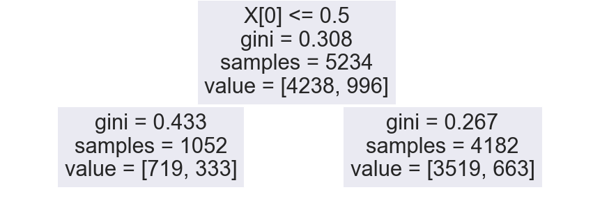

```python
tree_best_model = DecisionTreeClassifier(min_samples_split=2, max_depth=1)
tree_best_model.fit(X_train, y_train)

tree_pred_2 = tree_best_model.predict(X_val)

plot_tree(tree_best_model)
```

```python
print(confusion_matrix(y_val, tree_pred_2))
print("\n")
print(classification_report(y_val, tree_pred_2))
```

```
[[1807    0]
 [ 437    0]]


              precision    recall  f1-score   support

           0       0.81      1.00      0.89      1807
           1       0.00      0.00      0.00       437

    accuracy                           0.81      2244
   macro avg       0.40      0.50      0.45      2244
weighted avg       0.65      0.81      0.72      2244
```

# Q5

## Random Forest model

- Initiate the Random Forest classifier from the sklearn library. Keep all parameters with their default values. (No need to specify anything)
- Fit the model
- Make predictions
- Calculate accuracy score. What are the **training** and **testing** accuracies of the model?
- Create confusion matrix
- Either using the confusion matrix or the methods in `sklearn.metrics` get the following metrics on the testing set:
  - Recall (Sensitivity)
  - Specificity
  - Precision
  - Balanced Accuracy
  - F1 Score
- Using all the training data perform cross-validation:
  - Select the `min_samples_split` hyper-parameter and apply cross validation to find the best value.
  - Select the `max_depth` hyper-parameter and apply cross validation to find the best value.
  - Select the `n_estimators` hyper-parameter and apply cross validation to find the best value.
  - Perform grid search where you check for combinations of these hyper-parameters.
    - https://scikit-learn.org/stable/modules/generated/sklearn.model_selection.GridSearchCV.html
- For the best model:
  - Either using the confusion matrix or the methods in `sklearn.metrics` get the following metrics on the testing set:
    - Recall (Sensitivity)
    - Specificity
    - Precision
    - Balanced Accuracy
    - F1 Score
  - Compare the results to the model with default paramters. Any change?

```python
from sklearn.ensemble import RandomForestClassifier
```

```python
RandomForestClassifier()
```

```
RandomForestClassifier()
```

```python
rf_model = RandomForestClassifier()

rf_model.fit(X_train, y_train)

rf_pred = rf_model.predict(X_val)
```

```python
rf_acc = accuracy_score(y_val, rf_pred)

print(rf_acc)
```

```
0.803030303030303
```

```python
print(confusion_matrix(y_val, rf_pred))
print("\n")
print(classification_report(y_val, rf_pred))
```

```
[[1791   16]
 [ 426   11]]


              precision    recall  f1-score   support

           0       0.81      0.99      0.89      1807
           1       0.41      0.03      0.05       437

    accuracy                           0.80      2244
   macro avg       0.61      0.51      0.47      2244
weighted avg       0.73      0.80      0.73      2244
```

```python
classifier = RandomForestClassifier(min_samples_split=5 , max_depth=5 , n_estimators=100 )

RF_accuracies = cross_val_score(estimator=classifier, X=X_train, y=y_train, cv=5)

print(RF_accuracies)
```

```
[0.80993314 0.80993314 0.80897803 0.80897803 0.80975143]
```

```python
grid_param = {
    'max_depth' : [1,2,3,4,5,6,7,8,9,10],
    'min_samples_split' : [1,2,3,4,5,6,7,8,9,10],
    'n_estimators' : [10,50,100,150]
}

gd_sr = GridSearchCV(estimator=classifier,
                     param_grid=grid_param,
                     scoring='accuracy',
                     cv=5,
                     n_jobs=-1)

gd_sr.fit(X_train, y_train)

best_parameters = gd_sr.best_params_
print(best_parameters)
```

[output not shown]

[output cut: 13 more lines]

[output not shown]

```
{'max_depth': 10, 'min_samples_split': 4, 'n_estimators': 50}
```

```python
rf_model_2 = RandomForestClassifier(min_samples_split=4 , max_depth=10 , n_estimators=50)

rf_model_2.fit(X_train, y_train)

rf_pred_2 = rf_model_2.predict(X_val)
```

```python
print(confusion_matrix(y_val, rf_pred_2))
print("\n")
print(classification_report(y_val, rf_pred_2))
```

```
[[1800    7]
 [ 427   10]]


              precision    recall  f1-score   support

           0       0.81      1.00      0.89      1807
           1       0.59      0.02      0.04       437

    accuracy                           0.81      2244
   macro avg       0.70      0.51      0.47      2244
weighted avg       0.77      0.81      0.73      2244
```

For the RandomForest classifier, there was little change in the models as the accuracy for the model with default parameters is 80% and the accuracy for the "Best Model" is 81%.

# Q6

## Adaboost model

- Initiate the Random Forest classifier from the sklearn library. Keep all parameters with their default values. (No need to specify anything)
- Fit the model
- Make predictions
- Calculate accuracy score. What are the **training** and **testing** accuracies of the model?
- Create confusion matrix
- Either using the confusion matrix or the methods in `sklearn.metrics` get the following metrics on the testing set:
  - Recall (Sensitivity)
  - Specificity
  - Precision
  - Balanced Accuracy
  - F1 Score
- Using all the training data perform cross-validation:
  - Select the `learning_rate` hyper-parameter and apply cross validation to find the best value.
  - Select the `n_estimators` hyper-parameter and apply cross validation to find the best value.
  - Perform grid search where you check for combinations of these hyper-parameters.
    - https://scikit-learn.org/stable/modules/generated/sklearn.model_selection.GridSearchCV.html
- For the best model:
  - Either using the confusion matrix or the methods in `sklearn.metrics` get the following metrics on the testing set:
    - Recall (Sensitivity)
    - Specificity
    - Precision
    - Balanced Accuracy
    - F1 Score
  - Compare the results to the model with default paramters. Any change?

```python
from sklearn.ensemble import AdaBoostClassifier
```

```python
AdaBoostClassifier()
```

```
AdaBoostClassifier()
```

```python
ada_model = AdaBoostClassifier()

ada_model.fit(X_train, y_train)

ada_pred = ada_model.predict(X_val)
```

```python
ada_acc = accuracy_score(y_val, ada_pred)

print(ada_acc)
```

```
0.803475935828877
```

```python
print(confusion_matrix(y_val, ada_pred))
print("\n")
print(classification_report(y_val, ada_pred))
```

```
[[1786   21]
 [ 420   17]]


              precision    recall  f1-score   support

           0       0.81      0.99      0.89      1807
           1       0.45      0.04      0.07       437

    accuracy                           0.80      2244
   macro avg       0.63      0.51      0.48      2244
weighted avg       0.74      0.80      0.73      2244
```

```python
classifier = AdaBoostClassifier()

Ada_accuracies = cross_val_score(estimator=classifier, X=X_train, y=y_train, cv=5)

print(Ada_accuracies)
```

```
[0.81184336 0.80420248 0.79942693 0.80897803 0.79732314]
```

```python
grid_param = {
    'learning_rate' : [.1,.2,.3,4.,.5,.6,.7,.8,.9,1.0],
    'n_estimators' : [10,50,100,150]
}

gd_sr = GridSearchCV(estimator=classifier,
                     param_grid=grid_param,
                     scoring='accuracy',
                     cv=5,
                     n_jobs=-1)

gd_sr.fit(X_train, y_train)

best_parameters = gd_sr.best_params_
print(best_parameters)
```

```
{'learning_rate': 0.2, 'n_estimators': 50}
```

```python
ada_model_2 = AdaBoostClassifier(learning_rate=0.2 , n_estimators=50)

ada_model_2.fit(X_train, y_train)

ada_pred_2 = ada_model_2.predict(X_val)
```

```python
print(confusion_matrix(y_val, ada_pred_2))
print("\n")
print(classification_report(y_val, ada_pred_2))
```

```
[[1807    0]
 [ 436    1]]


              precision    recall  f1-score   support

           0       0.81      1.00      0.89      1807
           1       1.00      0.00      0.00       437

    accuracy                           0.81      2244
   macro avg       0.90      0.50      0.45      2244
weighted avg       0.84      0.81      0.72      2244
```

For the AdaBoost classifier, there was little change between the two models. The accuracy for the "Best Model" is 81%, while the accuracy for the default model is 80%

# Q7

## Gradient Boost model

- Initiate the Random Forest classifier from the sklearn library. Keep all parameters with their default values. (No need to specify anything)
- Fit the model
- Make predictions
- Calculate accuracy score. What are the **training** and **testing** accuracies of the model?
- Create confusion matrix
- Either using the confusion matrix or the methods in `sklearn.metrics` get the following metrics on the testing set:
  - Recall (Sensitivity)
  - Specificity
  - Precision
  - Balanced Accuracy
  - F1 Score
- Using all the training data perform cross-validation:
  - Select the `learning_rate` hyper-parameter and apply cross validation to find the best value.
  - Select the `n_estimators` hyper-parameter and apply cross validation to find the best value.
  - Perform grid search where you check for combinations of these hyper-parameters.
    - https://scikit-learn.org/stable/modules/generated/sklearn.model_selection.GridSearchCV.html
- For the best model:
  - Either using the confusion matrix or the methods in `sklearn.metrics` get the following metrics on the testing set:
    - Recall (Sensitivity)
    - Specificity
    - Precision
    - Balanced Accuracy
    - F1 Score
  - Compare the results to the model with default paramters. Any change?

```python
from sklearn.ensemble import GradientBoostingClassifier
```

```python
GradientBoostingClassifier()
```

```
GradientBoostingClassifier()
```

```python
grad_model = GradientBoostingClassifier()

grad_model.fit(X_train, y_train)

grad_pred = grad_model.predict(X_val)
```

```python
grad_acc = accuracy_score(y_val, grad_pred)

print(grad_acc)
```

```
0.8057040998217468
```

```python
print(confusion_matrix(y_val, grad_pred))
print("\n")
print(classification_report(y_val, grad_pred))
```

```
[[1791   16]
 [ 420   17]]


              precision    recall  f1-score   support

           0       0.81      0.99      0.89      1807
           1       0.52      0.04      0.07       437

    accuracy                           0.81      2244
   macro avg       0.66      0.52      0.48      2244
weighted avg       0.75      0.81      0.73      2244
```

```python
classifier = GradientBoostingClassifier()

Grad_accuracies = cross_val_score(estimator=classifier, X=X_train, y=y_train, cv=5)

print(Grad_accuracies)
```

```
[0.80897803 0.8061127  0.8061127  0.80802292 0.80497132]
```

```python
grid_param = {
    'learning_rate' : [.1,.2,.3,4.,.5,.6,.7,.8,.9,1.0],
    'n_estimators' : [10,50,100,150]
}

gd_sr = GridSearchCV(estimator=classifier,
                     param_grid=grid_param,
                     scoring='accuracy',
                     cv=5,
                     n_jobs=-1)

gd_sr.fit(X_train, y_train)

best_parameters = gd_sr.best_params_
print(best_parameters)
```

```
{'learning_rate': 0.2, 'n_estimators': 10}
```

```python
grad_model_2 = GradientBoostingClassifier(learning_rate=0.2 , n_estimators=10)

grad_model_2.fit(X_train, y_train)

grad_pred_2 = grad_model_2.predict(X_val)
```

```python
print(confusion_matrix(y_val, grad_pred_2))
print("\n")
print(classification_report(y_val, grad_pred_2))
```

```
[[1804    3]
 [ 434    3]]


              precision    recall  f1-score   support

           0       0.81      1.00      0.89      1807
           1       0.50      0.01      0.01       437

    accuracy                           0.81      2244
   macro avg       0.65      0.50      0.45      2244
weighted avg       0.75      0.81      0.72      2244
```

For the GradientBoosting classifier, the accuracy was 81% for both the default model and the "Best Model".

# Q8

- Using the Decision Tree, Random Forest, Adaboost, and Gradient Boosting classifer models:
  - Think of other ways of improving the accuracy and list at least two possibilities.
  - Implement both of the methods you proposed.
  - Is the model recall increasing? Why do you think this might have helped?
  - If both of them did not improve, comment on why this might have been the case.
  - Optional: Apply different things and see if the recall is improving

Model accurracy can be improved by several methods. In some cases, adding more data can show an improvement in model accuracy. Another method is feature selection. Additional methods are algorithm tuning, ensemble methods (bagging and boosting) and cross validation.

The Bagging ensemble method will be used to generate models for the Decision Tree, Random Forest, Adaboost and Gradient Boosting models.

```python
from sklearn.ensemble import BaggingClassifier

bag_tree_model = BaggingClassifier(base_estimator=DecisionTreeClassifier())

bag_tree_model.fit(X_train, y_train)

bag_tree_pred = bag_tree_model.predict(X_val)

print(confusion_matrix(y_val, bag_tree_pred ))
print("\n")
print(classification_report(y_val, bag_tree_pred))
```

```
[[1747   60]
 [ 402   35]]


              precision    recall  f1-score   support

           0       0.81      0.97      0.88      1807
           1       0.37      0.08      0.13       437

    accuracy                           0.79      2244
   macro avg       0.59      0.52      0.51      2244
weighted avg       0.73      0.79      0.74      2244
```

```python
bag_rf_model = BaggingClassifier(base_estimator=RandomForestClassifier())

bag_rf_model.fit(X_train, y_train)

bag_rf_pred = bag_rf_model.predict(X_val)

print(confusion_matrix(y_val, bag_rf_pred ))
print("\n")
print(classification_report(y_val, bag_rf_pred))
```

```
[[1805    2]
 [ 429    8]]


              precision    recall  f1-score   support

           0       0.81      1.00      0.89      1807
           1       0.80      0.02      0.04       437

    accuracy                           0.81      2244
   macro avg       0.80      0.51      0.46      2244
weighted avg       0.81      0.81      0.73      2244
```

```python
bag_ada_model = BaggingClassifier(base_estimator=AdaBoostClassifier())

bag_ada_model.fit(X_train, y_train)

bag_ada_pred = bag_ada_model.predict(X_val)

print(confusion_matrix(y_val, bag_ada_pred ))
print("\n")
print(classification_report(y_val, bag_ada_pred))
```

```
[[1792   15]
 [ 428    9]]


              precision    recall  f1-score   support

           0       0.81      0.99      0.89      1807
           1       0.38      0.02      0.04       437

    accuracy                           0.80      2244
   macro avg       0.59      0.51      0.46      2244
weighted avg       0.72      0.80      0.72      2244
```

```python
bag_grad_model = BaggingClassifier(base_estimator=GradientBoostingClassifier())

bag_grad_model.fit(X_train, y_train)

bag_grad_pred = bag_grad_model.predict(X_val)

print(confusion_matrix(y_val, bag_grad_pred ))
print("\n")
print(classification_report(y_val, bag_grad_pred))
```

```
[[1794   13]
 [ 423   14]]


              precision    recall  f1-score   support

           0       0.81      0.99      0.89      1807
           1       0.52      0.03      0.06       437

    accuracy                           0.81      2244
   macro avg       0.66      0.51      0.48      2244
weighted avg       0.75      0.81      0.73      2244
```

The above models were fitted using the Ensemble method of Bagging. The models are being compared to the "Best Models", in the previous question.

The following models were adjusted via algorithm tuning. The hyper-parameters for each classifier were adjusted to find an ideal "Best Fit" model.

```python
tree_model_3 = DecisionTreeClassifier(min_samples_split=3, max_depth=4)
tree_model_3.fit(X_train, y_train)

tree_pred_3 = tree_best_model.predict(X_val)

print(confusion_matrix(y_val, tree_pred_3))
print("\n")
print(classification_report(y_val, tree_pred_3))
```

```
[[1807    0]
 [ 437    0]]


              precision    recall  f1-score   support

           0       0.81      1.00      0.89      1807
           1       0.00      0.00      0.00       437

    accuracy                           0.81      2244
   macro avg       0.40      0.50      0.45      2244
weighted avg       0.65      0.81      0.72      2244
```

```python
rf_model_3 = RandomForestClassifier(min_samples_split=5 , max_depth=5 , n_estimators=100)

rf_model_3.fit(X_train, y_train)

rf_pred_3 = rf_model_3.predict(X_val)

print(confusion_matrix(y_val, rf_pred_3))
print("\n")
print(classification_report(y_val, rf_pred_3))
```

```
[[1807    0]
 [ 437    0]]


              precision    recall  f1-score   support

           0       0.81      1.00      0.89      1807
           1       0.00      0.00      0.00       437

    accuracy                           0.81      2244
   macro avg       0.40      0.50      0.45      2244
weighted avg       0.65      0.81      0.72      2244
```

```python
ada_model_3 = AdaBoostClassifier(learning_rate=0.3 , n_estimators=100)

ada_model_3.fit(X_train, y_train)

ada_pred_3 = ada_model_3.predict(X_val)

print(confusion_matrix(y_val, ada_pred_3))
print("\n")
print(classification_report(y_val, ada_pred_3))
```

```
[[1802    5]
 [ 432    5]]


              precision    recall  f1-score   support

           0       0.81      1.00      0.89      1807
           1       0.50      0.01      0.02       437

    accuracy                           0.81      2244
   macro avg       0.65      0.50      0.46      2244
weighted avg       0.75      0.81      0.72      2244
```

```python
grad_model_3 = GradientBoostingClassifier(learning_rate=0.1 , n_estimators=20)

grad_model_3.fit(X_train, y_train)

grad_pred_3 = grad_model_3.predict(X_val)

print(confusion_matrix(y_val, grad_pred_3))
print("\n")
print(classification_report(y_val, grad_pred_3))
```

```
[[1807    0]
 [ 436    1]]


              precision    recall  f1-score   support

           0       0.81      1.00      0.89      1807
           1       1.00      0.00      0.00       437

    accuracy                           0.81      2244
   macro avg       0.90      0.50      0.45      2244
weighted avg       0.84      0.81      0.72      2244
```

For each classifier, there was no real improvement using the Ensemble Bagging method and using parameter tuning. Its possible that one of the other methods could be successful in displaying improved or more accurate models.

# Q9

- Choose the best fitted model for each of teh classifiers (1 model for each of Decision Tree, Random Forest, Adaboost, and Gradient Boosting)
- Create a table summarizing results on the test set:
  - Create confusion matrix for each model
  - Either using the confusion matrix or the methods in `sklearn.metrics` get the following metrics on the testing set:
    - Recall (Sensitivity)
    - Specificity
    - Precision
    - Balanced Accuracy
    - F1 Score

Best Decision Tree Model:

```python
print(confusion_matrix(y_val, tree_pred_2))
print("\n")
print(classification_report(y_val, tree_pred_2))
```

```
[[1807    0]
 [ 437    0]]


              precision    recall  f1-score   support

           0       0.81      1.00      0.89      1807
           1       0.00      0.00      0.00       437

    accuracy                           0.81      2244
   macro avg       0.40      0.50      0.45      2244
weighted avg       0.65      0.81      0.72      2244
```

Best Random Forest Model:

```python
print(confusion_matrix(y_val, rf_pred_2))
print("\n")
print(classification_report(y_val, rf_pred_2))
```

```
[[1800    7]
 [ 427   10]]


              precision    recall  f1-score   support

           0       0.81      1.00      0.89      1807
           1       0.59      0.02      0.04       437

    accuracy                           0.81      2244
   macro avg       0.70      0.51      0.47      2244
weighted avg       0.77      0.81      0.73      2244
```

Best Ada Boost Model:

```python
print(confusion_matrix(y_val, ada_pred_2))
print("\n")
print(classification_report(y_val, ada_pred_2))
```

```
[[1807    0]
 [ 436    1]]


              precision    recall  f1-score   support

           0       0.81      1.00      0.89      1807
           1       1.00      0.00      0.00       437

    accuracy                           0.81      2244
   macro avg       0.90      0.50      0.45      2244
weighted avg       0.84      0.81      0.72      2244
```

Best Gradient Boosting Model:

```python
print(confusion_matrix(y_val, grad_pred_2))
print("\n")
print(classification_report(y_val, grad_pred_2))
```

```
[[1804    3]
 [ 434    3]]


              precision    recall  f1-score   support

           0       0.81      1.00      0.89      1807
           1       0.50      0.01      0.01       437

    accuracy                           0.81      2244
   macro avg       0.65      0.50      0.45      2244
weighted avg       0.75      0.81      0.72      2244
```

# Q10

- Choose a winner model.
- Make predictions on the hold-out set whose outcome variables are not known (data we imported as: `loans_outcome_not_known`).
- Write the code below to make predictions with this model. At the end it should output the prediction of the labels.
- Save the predictions in a csv file
- There should be a single column in the csv file.
- The column header should be 'predictions'
- Your prediction performance will be calculated and a ranking will be performed

```python
loans_outcome_not_known.head()
```

|  | credit.policy | purpose | int.rate | installment | log.annual.inc | dti | fico | days.with.cr.line | revol.bal | revol.util | inq.last.6mths | delinq.2yrs | pub.rec |
| --- | --- | --- | --- | --- | --- | --- | --- | --- | --- | --- | --- | --- | --- |
| 0 | 1 | debt_consolidation | 0.1324 | 540.96 | 10.596635 | 11.73 | 672 | 3210.000000 | 5671 | 55.1 | 0 | 0 | 0 |
| 1 | 0 | educational | 0.1221 | 333.15 | 11.156193 | 15.82 | 707 | 5314.000000 | 107643 | 81.0 | 3 | 0 | 0 |
| 2 | 1 | debt_consolidation | 0.1218 | 166.50 | 10.753836 | 6.38 | 772 | 1440.000000 | 233 | 6.7 | 0 | 0 | 0 |
| 3 | 0 | major_purchase | 0.1461 | 124.12 | 10.239960 | 0.00 | 692 | 1530.041667 | 0 | 0.0 | 6 | 0 | 0 |
| 4 | 1 | credit_card | 0.0800 | 156.69 | 10.434116 | 15.85 | 767 | 10170.000000 | 5748 | 12.3 | 0 | 1 | 0 |

```python
# print(X_train)

# print(loans_outcome_not_known)

category_feats = ['purpose']

loans_not_known = pd.get_dummies(data=loans_outcome_not_known ,columns=category_feats)

ada_pred_final = ada_model_2.predict(loans_not_known)

# print(ada_pred_final)

# print(type(ada_pred_final))

np.savetxt('predictions.csv', ada_pred_final, delimiter=' ', fmt="%.0f", header='predictions', comments='')
```